# Momentum in the MLB 2021

Anthony Fernandez

2025-05-25

```r
devtools::install_github("billpetti/baseballr")

library(baseballr)
library(dplyr)
library(purrr)
library(lubridate)
library(tidyverse)


# Load required packages
library(data.table)
library(dplyr)
library(purrr)
```

```r
# Safe Downloader
get_statcast_data_weekly <- function(start_date, end_date) {
  url <- paste0(
    "https://baseballsavant.mlb.com/statcast_search/csv?all=true",
    "&hfPT=&hfAB=&hfBBT=&hfPR=&hfZ=&stadium=&hfBBL=&hfNewZones=&hfGT=R%7CPO%7CS%7C",
    "&hfC&hfSit=&hfOuts=&opponent=&pitcher_throws=&batter_stands=",
    "&hfSA=&player_type=batter&hfInfield=&team=&position=&hfOutfield=",
    "&hfRO=&home_road=&game_date_gt=", start_date,
    "&game_date_lt=", end_date,
    "&group_by=name&sort_col=pitches&player_event_sort=h_launch_speed",
    "&sort_order=desc&type=details"
  )

  message(paste("Downloading:", start_date, "to", end_date))
  tryCatch({
    fread(url, showProgress = FALSE, fill = TRUE)
  }, error = function(e) {
    message("Failed:", e$message)
    NULL
  })
}
```

```r
# Defined weekly ranges for 2021 regular season
dates_2021 <- data.frame(
  start = c("2021-04-01", "2021-04-08", "2021-04-15", "2021-04-22", "2021-04-29",
            "2021-05-06", "2021-05-13", "2021-05-20", "2021-05-27",
            "2021-06-03", "2021-06-10", "2021-06-17", "2021-06-24",
            "2021-07-01", "2021-07-08", "2021-07-15", "2021-07-22", "2021-07-29",
            "2021-08-05", "2021-08-12", "2021-08-19", "2021-08-26",
            "2021-09-02", "2021-09-09", "2021-09-16", "2021-09-23", "2021-09-30"),
  end = c("2021-04-07", "2021-04-14", "2021-04-21", "2021-04-28", "2021-05-05",
          "2021-05-12", "2021-05-19", "2021-05-26", "2021-06-02",
          "2021-06-09", "2021-06-16", "2021-06-23", "2021-06-30",
          "2021-07-07", "2021-07-14", "2021-07-21", "2021-07-28", "2021-08-04",
          "2021-08-11", "2021-08-18", "2021-08-25", "2021-09-01",
          "2021-09-08", "2021-09-15", "2021-09-22", "2021-09-29", "2021-10-03")
)

# Updated function using the exported method
get_statcast_data_weekly <- function(start_date, end_date) {
  message("Downloading: ", start_date, " to ", end_date)
  baseballr::scrape_statcast_savant_batter(start_date, end_date)
}

# Run the download loop
#statcast_2021 <- purrr::map2_dfr(dates_2021$start, dates_2021$end, get_statcast_data_weekly)

# Save result
#saveRDS(statcast_2021, "statcast_2021_full.rds")

statcast_2021 <- readRDS("statcast_2021_full.rds")
```

```r
#summary(statcast_2021)

cols_to_keep <- c(
  "game_pk",             # Game ID
  "game_date",           # Date of game
  "at_bat_number",       # Sequential number of PA in game
  "inning",              # Inning
  "inning_topbot",       # Top or Bottom of inning
  "batter",              # Batter ID
  "player_name",         # Batter name
  "events",              # Event result (e.g. 'single', 'groundout')
  "description",         # Useful for identifying completed PAs
  "home_team",           # Home team
  "away_team",           # Away team
  "bat_score",           # Score at the time
  "post_bat_score",      # Score after PA
  "home_score", "away_score", # Full context
  "pitch_number"         # Needed to make sure we're only using the final pitch of the PA
)

statcast_2021_clean <- statcast_2021 %>%
  select(all_of(cols_to_keep)) %>%
  filter(!is.na(events))

# Check result
glimpse(statcast_2021_clean)
```

```
## Rows: 657,215
## Columns: 16
## $ game_pk        <dbl> 634567, 634567, 634567, 634567, 634567, 634567, 634567,…
## $ game_date      <date> 2021-04-07, 2021-04-07, 2021-04-07, 2021-04-07, 2021-0…
## $ at_bat_number  <dbl> 60, 60, 60, 60, 59, 59, 59, 43, 59, 42, 48, 48, 59, 42,…
## $ inning         <dbl> 7, 7, 7, 7, 7, 7, 7, 6, 7, 6, 7, 7, 7, 6, 6, 6, 7, 7, 6…
## $ inning_topbot  <chr> "Bot", "Bot", "Bot", "Bot", "Bot", "Bot", "Bot", "Top",…
## $ batter         <dbl> 462101, 462101, 462101, 462101, 572039, 572039, 572039,…
## $ player_name    <chr> "Andrus, Elvis", "Andrus, Elvis", "Andrus, Elvis", "And…
## $ events         <chr> "strikeout", "", "", "", "single", "", "", "single", ""…
## $ description    <chr> "swinging_strike", "ball", "swinging_strike", "called_s…
## $ home_team      <chr> "OAK", "OAK", "OAK", "OAK", "OAK", "OAK", "OAK", "OAK",…
## $ away_team      <chr> "LAD", "LAD", "LAD", "LAD", "LAD", "LAD", "LAD", "LAD",…
## $ bat_score      <dbl> 2, 2, 2, 2, 2, 2, 2, 1, 2, 1, 1, 1, 2, 1, 1, 0, 1, 2, 0…
## $ post_bat_score <dbl> 2, 2, 2, 2, 2, 2, 2, 1, 2, 1, 1, 1, 2, 1, 1, 0, 1, 2, 0…
## $ home_score     <dbl> 2, 2, 2, 2, 2, 2, 2, 1, 2, 1, 2, 2, 2, 1, 1, 0, 2, 2, 0…
## $ away_score     <dbl> 3, 3, 3, 3, 3, 3, 3, 1, 3, 1, 1, 1, 3, 1, 1, 0, 1, 3, 0…
## $ pitch_number   <dbl> 4, 3, 2, 1, 5, 4, 3, 1, 2, 4, 5, 4, 1, 3, 2, 4, 3, 5, 3…
```

```r
unique(statcast_2021$events)
```

```
##  [1] "strikeout"                 ""
##  [3] "single"                    "walk"
##  [5] "field_out"                 "home_run"
##  [7] "truncated_pa"              "force_out"
##  [9] "hit_by_pitch"              "grounded_into_double_play"
## [11] "double"                    "field_error"
## [13] "double_play"               "sac_bunt"
## [15] "sac_fly"                   "fielders_choice_out"
## [17] "triple"                    "catcher_interf"
## [19] "fielders_choice"           "strikeout_double_play"
## [21] "sac_fly_double_play"       "triple_play"
## [23] "sac_bunt_double_play"
```

```r
# Keep only the final pitch of each at-bat (where event is not NA and last pitch_number per at_bat)
library(dplyr)

statcast_pa_2021 <- statcast_2021_clean %>%
  filter(!is.na(events), events != "") %>%
  group_by(game_pk, at_bat_number) %>%
  filter(pitch_number == max(pitch_number)) %>%
  ungroup()
```

```r
# Sort by game, inning, top/bot, and at-bat
statcast_pa_2021 <- statcast_pa_2021 %>%
  arrange(game_pk, inning, inning_topbot, at_bat_number) %>%
  group_by(game_pk, inning, inning_topbot) %>%
  mutate(
    prev_event = lag(events),
    prev_batter = lag(batter),
    momentum = ifelse(prev_event %in% c("single", "double", "triple", "home_run", "sac_fly"), 1, 0)
  ) %>%
  ungroup()
```

```r
# Calculate batting average with vs. without momentum
momentum_ba <- statcast_pa_2021 %>%
  filter(events %in% c(
    "single", "double", "triple", "home_run",
    "field_out", "strikeout", "grounded_into_double_play",
    "double_play", "strikeout_double_play",
    "fielders_choice", "force_out"
  )) %>%
  mutate(hit = ifelse(events %in% c("single", "double", "triple", "home_run"), 1, 0)) %>%
  group_by(momentum) %>%
  summarise(
    PA = n(),
    Hits = sum(hit),
    Batting_Average = mean(hit)
  )

print(momentum_ba)
```

```
## # A tibble: 2 × 4
##   momentum     PA  Hits Batting_Average
##      <dbl>  <int> <dbl>           <dbl>
## 1        0 116716 28247           0.242
## 2        1  32190  8359           0.260
```

########Break Down by Team################## ############################################

```r
statcast_pa_2021 <- statcast_pa_2021 %>%
  mutate(batting_team = ifelse(inning_topbot == "Top", away_team, home_team))

statcast_pa_2021 <- statcast_pa_2021 %>%
  mutate(hit = ifelse(events %in% c("single", "double", "triple", "home_run"), 1, 0))
```

```r
library(dplyr)

team_momentum_ba <- statcast_pa_2021 %>%
 filter(events %in% c(
    "single", "double", "triple", "home_run",
    "field_out", "strikeout", "grounded_into_double_play",
    "double_play", "strikeout_double_play",
    "fielders_choice", "force_out"
  )) %>%
  group_by(batting_team, momentum) %>%
  summarise(
    PA = n(),
    Hits = sum(hit),
    Batting_Average = mean(hit),
    .groups = "drop"
  )
```

```r
library(tidyr)

team_comparison_21 <- team_momentum_ba %>%
  pivot_wider(
    names_from = momentum,
    values_from = c(PA, Hits, Batting_Average),
    names_prefix = "momentum_"
  ) %>%
  mutate(
    BA_Difference = Batting_Average_momentum_1 - Batting_Average_momentum_0
  ) %>%
  arrange(desc(BA_Difference))

# View top teams by momentum boost
print(team_comparison_21)
```

```
## # A tibble: 30 × 8
##    batting_team PA_momentum_0 PA_momentum_1 Hits_momentum_0 Hits_momentum_1
##    <chr>                <int>         <int>           <dbl>           <dbl>
##  1 ATL                   3805          1078             919             301
##  2 CLE                   3827          1060             888             283
##  3 STL                   3851          1107             931             303
##  4 MIN                   3958          1088             937             290
##  5 MIL                   3960           981             906             253
##  6 COL                   3858          1085             943             293
##  7 WSH                   3805          1121             977             316
##  8 SEA                   3964           995             885             247
##  9 LAD                   3983          1068             965             285
## 10 PIT                   3865          1015             903             261
## # ℹ 20 more rows
## # ℹ 3 more variables: Batting_Average_momentum_0 <dbl>,
## #   Batting_Average_momentum_1 <dbl>, BA_Difference <dbl>
```

```r
#write.csv(team_comparison_21, "team_comparison_21.csv", row.names = FALSE)
```

```r
# Total hits in cleaned dataset
sum(statcast_pa_2021$hit, na.rm = TRUE)
```

```
## [1] 36606
```

```r
# Total hits from your momentum breakdown
sum(team_comparison_21$Hits_momentum_0, na.rm = TRUE) +
sum(team_comparison_21$Hits_momentum_1, na.rm = TRUE)
```

```
## [1] 36606
```

The reason the total hits from the momentum breakdown (Hits_momentum_0 + Hits_momentum_1) don’t match official MLB hit totals is because my analysis only includes plate appearances with specific qualifying events (like hits, outs, and double plays), and excludes others like walks, hit-by-pitches, and sac bunts. Additionally, momentum can only be calculated when there’s a valid previous batter, so the first batter of each inning or game may be excluded. However, since my total hits from the filtered dataset match the combined momentum hits exactly (36,606), my momentum analysis is internally consistent and correctly reflects the subset of data I chose to study.

```r
# Filter valid at-bats and create the hit column
valid_pas <- statcast_pa_2021 %>%
  filter(events %in% c(
    "single", "double", "triple", "home_run",
    "field_out", "strikeout", "grounded_into_double_play",
    "double_play", "strikeout_double_play",
    "fielders_choice", "force_out"
  )) %>%
  mutate(hit = ifelse(events %in% c("single", "double", "triple", "home_run"), 1, 0))


t_test_result <- t.test(hit ~ momentum, data = valid_pas)

print(t_test_result)
```

```
##
##  Welch Two Sample t-test
##
## data:  hit by momentum
## t = -6.4304, df = 50398, p-value = 1.284e-10
## alternative hypothesis: true difference in means between group 0 and group 1 is not equal to 0
## 95 percent confidence interval:
##  -0.02304558 -0.01227864
## sample estimates:
## mean in group 0 mean in group 1
##       0.2420148       0.2596769
```

To statistically assess whether there is a significant difference in hitter performance following a momentum-generating event (defined as a hit or sac fly by the previous batter), my code ran a Welch Two Sample t-test comparing batting averages with and without momentum. The results show a statistically significant difference (t = -6.43, p-value < 0.0000000013), with batters hitting .2597 with momentum and .2420 without. The 95% confidence interval for the difference in means ranges from -0.0230 to -0.0123, indicating that the increase in batting average associated with momentum is not only statistically significant but also practically relevant in the context of baseball performance.

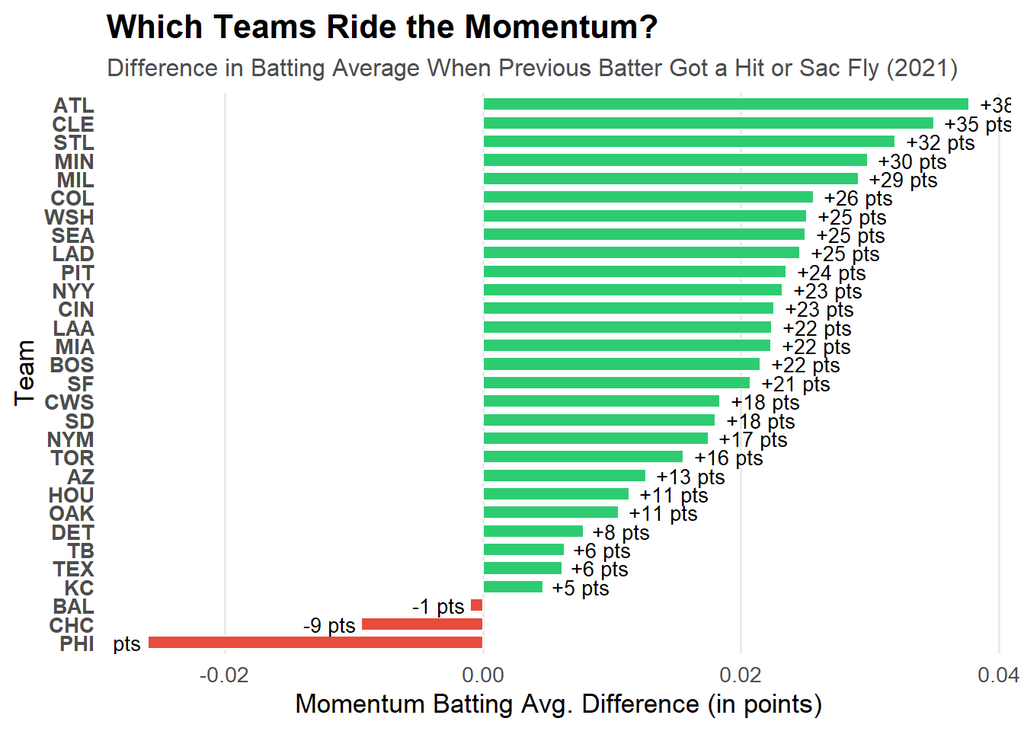

```r
library(ggplot2)

ggplot(team_comparison_21 %>% filter(!is.na(batting_team)),
       aes(x = reorder(batting_team, BA_Difference), y = BA_Difference, fill = BA_Difference > 0)) +
  geom_col(width = 0.7, color = "white", show.legend = FALSE) +
  scale_fill_manual(values = c("FALSE" = "#e74c3c", "TRUE" = "#2ecc71")) +
  geom_text(aes(label = sprintf("%+d pts", round(BA_Difference * 1000))),
            hjust = ifelse(team_comparison_21$BA_Difference > 0, -0.15, 1.1),
            size = 3.5, color = "black") +
  coord_flip() +
  labs(
    title = "Which Teams Ride the Momentum?",
    subtitle = "Difference in Batting Average When Previous Batter Got a Hit or Sac Fly (2021)",
    x = "Team",
    y = "Momentum Batting Avg. Difference (in points)"
  ) +
  theme_minimal(base_size = 13) +
  theme(
    plot.title = element_text(face = "bold", size = 16),
    plot.subtitle = element_text(color = "gray30", size = 12),
    panel.grid.major.y = element_blank(),
    panel.grid.minor = element_blank(),
    axis.text.y = element_text(face = "bold")
  )
```